# Exercise 4

Kyle M. Lang

Fundamental Techniques in Data Science with R

The following packages are required for this practical.

```r
library(dplyr)
library(magrittr)
library(mice)
```

If you’d like to replicate my results, you can set the random seed via:

```r
set.seed(235711)
```

# 1 Working with Pipes

When answering the questions in this section, use either the standard pipe, `%>%`, or the exposition pipe, `%$%`, to structure your solutions into pipelines, whenever possible.

## 1.1

**Complete the following steps in a single pipeline**

1. Use the `rnorm()` funciton to draw 1000 random values from a normal distribution with `mean = 5` and `sd = 1`
2. Place these random draws in a 500 $\times$ 2 matrix wherein the first 500 values populate the first column, and the second 500 values populate the second column.
3. Make a scatterplot of these two columns.

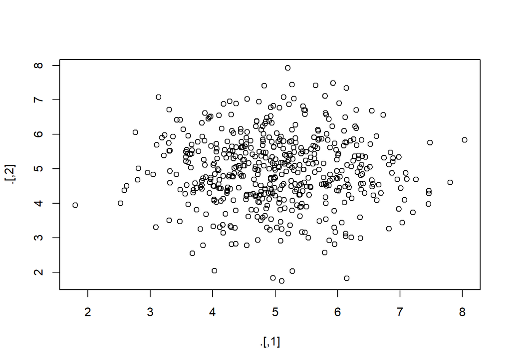

```r
rnorm(1000, 5) %>%
  matrix(ncol = 2) %>%
  plot()
```

## 1.2

**Calculate the correlation matrix of the `anscombe` data set**

```r
anscombe %>% cor()
```

```
##            x1         x2         x3         x4         y1         y2         y3
## x1  1.0000000  1.0000000  1.0000000 -0.5000000  0.8164205  0.8162365  0.8162867
## x2  1.0000000  1.0000000  1.0000000 -0.5000000  0.8164205  0.8162365  0.8162867
## x3  1.0000000  1.0000000  1.0000000 -0.5000000  0.8164205  0.8162365  0.8162867
## x4 -0.5000000 -0.5000000 -0.5000000  1.0000000 -0.5290927 -0.7184365 -0.3446610
## y1  0.8164205  0.8164205  0.8164205 -0.5290927  1.0000000  0.7500054  0.4687167
## y2  0.8162365  0.8162365  0.8162365 -0.7184365  0.7500054  1.0000000  0.5879193
## y3  0.8162867  0.8162867  0.8162867 -0.3446610  0.4687167  0.5879193  1.0000000
## y4 -0.3140467 -0.3140467 -0.3140467  0.8165214 -0.4891162 -0.4780949 -0.1554718
##            y4
## x1 -0.3140467
## x2 -0.3140467
## x3 -0.3140467
## x4  0.8165214
## y1 -0.4891162
## y2 -0.4780949
## y3 -0.1554718
## y4  1.0000000
```

## 1.3

**Calculate the correlation for the variables `x4` and `y4` from the `anscombe` data set**

Using the standard pipe:

```r
anscombe %>%
  subset(select = c(x4, y4)) %>%
  cor()
```

```
##           x4        y4
## x4 1.0000000 0.8165214
## y4 0.8165214 1.0000000
```

Using the exposition pipe:

```r
anscombe %$% cor(x4, y4)
```

```
## [1] 0.8165214
```

## 1.4

**Calculate the correlation between `hgt` and `wgt` in the `boys` dataset from the *mice* package**

The `boys` dataset has missings values on almost all variables, so we must do something to address the missing data (e.g., excluding incomplete cases) before calculating the correlation.

Using the standard pipe:

```r
boys %>%
  subset(select = c("wgt", "hgt")) %>%
  cor(use = "pairwise.complete.obs")
```

```
##           wgt       hgt
## wgt 1.0000000 0.9428906
## hgt 0.9428906 1.0000000
```

The `use = "pairwise.complete.obs"` argument tells the `cor()` function to use only cases that are non-missing for both `wgt` and `hgt` when calculating the correlation.

The above is equivalent to:

```r
boys %>%
  subset(select = c("wgt", "hgt")) %>%
  na.omit() %>%
  cor()
```

```
##           wgt       hgt
## wgt 1.0000000 0.9428906
## hgt 0.9428906 1.0000000
```

Notice that we selected the columns with which we would be working before running `na.omit()`. The `na.omit()` function excludes all incomplete cases, so we would throw out many more cases than necessary if we ran `na.omit()` on the entire dataset.

Alternatively, we can use the exposition pipe for a more elegant solution.

```r
boys %$% cor(hgt, wgt, use = "pairwise.complete.obs")
```

```
## [1] 0.9428906
```

The exposition pipe *exposes* the variable names of the `boys` dataset, so we can refer to them directly.

## 1.5

**Transform `hgt`**

In the `boys` dataset, `hgt` is recorded in centimeters.

1. Transform the scale of `hgt` to meters
2. Assign the transformed variable to a new column in the `boys` dataset named `hgt_meters`
3. Verify the transformation.

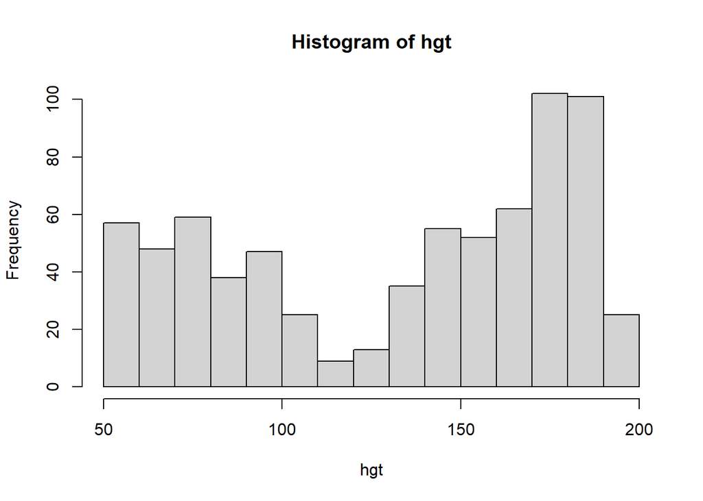

```r
boys <- boys %>% transform(hgt_meters = hgt / 100)

boys %$% hist(hgt)
```

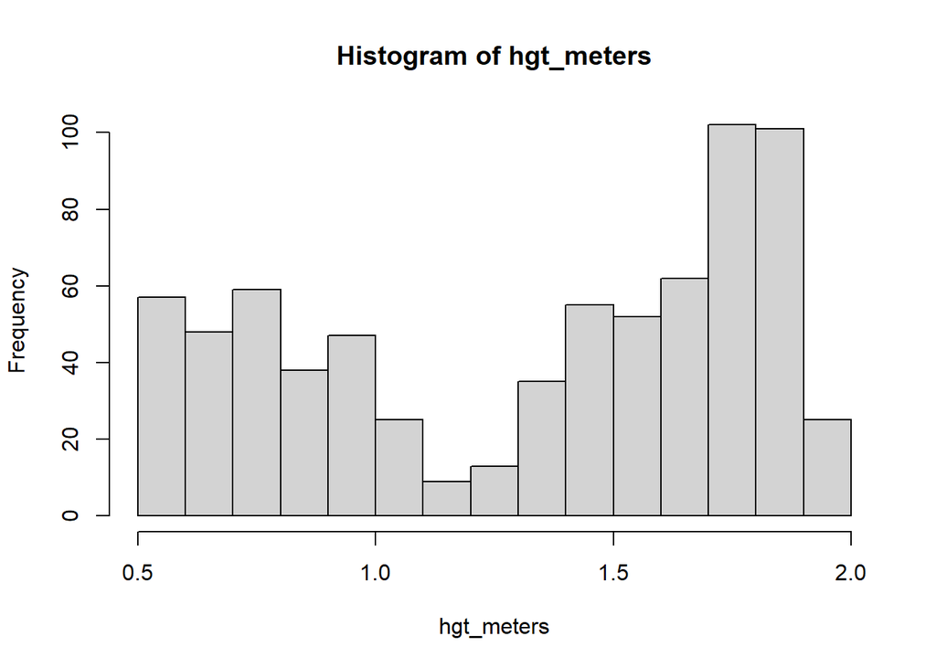

```r
boys %$% hist(hgt_meters)
```

## 1.6

**Create two scatterplots of *height* against *weight***

1. In the first figure, plot height in meters.
   - Make the points for the meters plot blue.
2. In the second figure, plot height in centimeters.
   - Make the points for the centimiters plot red.

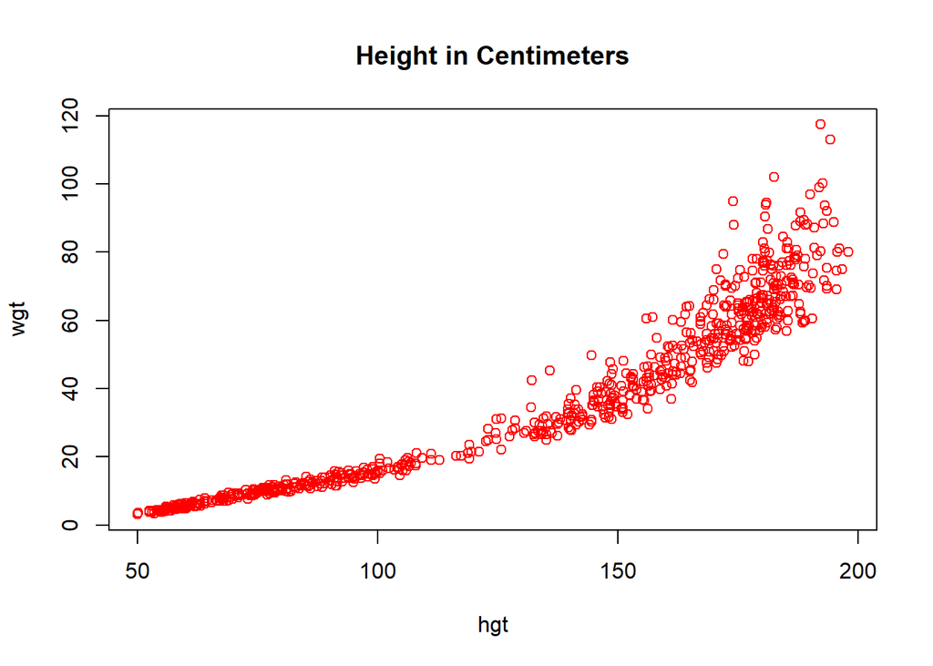

```r
boys %>%
  subset(select = c(hgt, wgt)) %>%
  plot(col = "red", main = "Height in Centimeters")
```

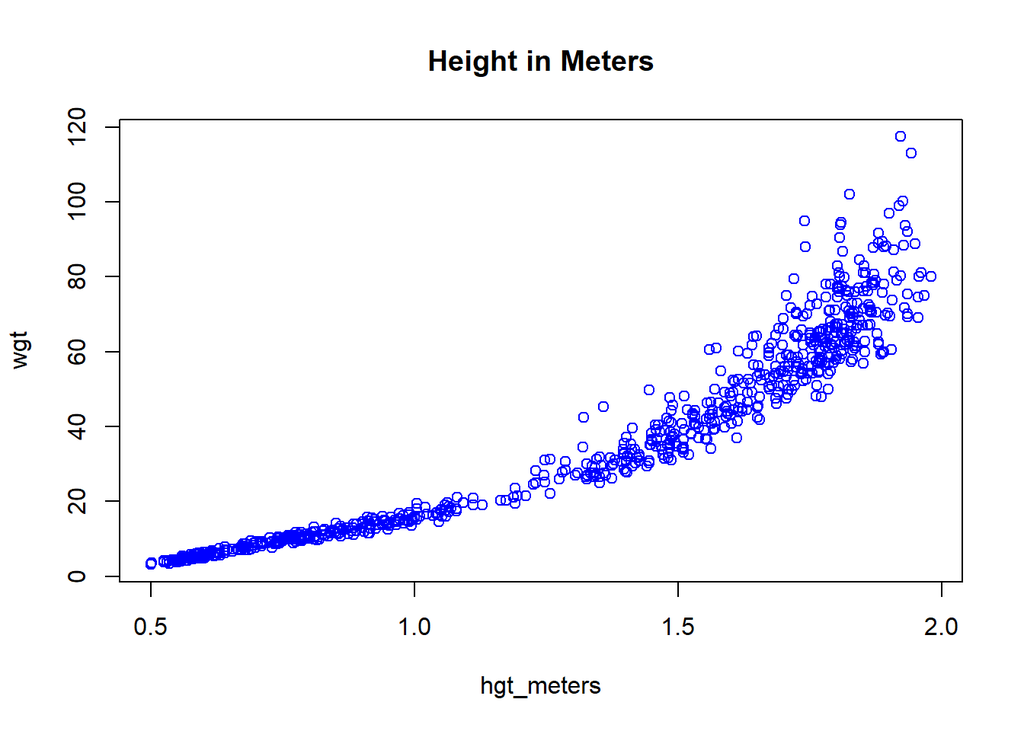

```r
boys %>%
  subset(select = c(hgt_meters, wgt)) %>%
  plot(col = "blue", main = "Height in Meters")
```

# 2 Working with Squared Deviations

In the following questions, you will investigate least-squares estimation of the mean. You can find the necessary data the workspace *exercise4_data.RData*.

You can load this workspace in two ways:

1. Download the workspace via the link above and load it into your environment manually with the `load()` function.
2. Create a connection to download the file from the course website, and load via that connection. The code for this approach is shown below.

```r
con <- url("https://www.kylemlang.com/fundamentals/wk2/exercise/data/exercise4_data.RData")
load(con)
```

The *exercise4_data.RData* workspace contains two vectors: `x` and `y`. Use these vectors to answer the following questions.

## 2.1

**Calculate the sample mean of the values in `x`**

```r
mean(x)
```

```
## [1] 3.909805
```

## 2.2

**Calculate the sum of squared deviations**

The values in `x` have been drawn from a population with mean $\mu = 3$ and standard deviation $\sigma = 7$. Calculate the sum of squared deviations from $\mu$.

- The sum of squared deviations from mu is defined as:
  $$\text{ssd} = \sum_{i = 1}^{N} (x_i - \mu)^2$$

```r
mu  <- 3
ssd <- sum((x - mu)^2)
```

# 3 User-Defined Functions

We have already seen many examples or R functions (e.g., `mean()`, `sum()`, `cor()`). As you progress in your programming/data analytic career, however, you will frequently encounter situations wherein it will be useful to define your own functions.

In R, we use the `function()` function to define a new function. The following pseudo code illustrates the usage of `function()`.

```r
myFunction <- function(arg1, arg2, ..., argN) {
  Code to do something using {arg1, arg2, ..., argN}
}
```

```r
stdAbsDiff <- function(x, y) {
  d <- x - y
  (d - mean(d)) / sd(d)
}
```

Notice how the code inside our function only uses data that we pass into the function as arguments (`x` and `y`, in this case).

- In nearly all circumstances, your function should only use its arguments to derive its return value (i.e., the value produced when you run the function).
- R uses something called *lexical scoping* to find the data used for a calculation.
  - Thanks to lexical scoping, it is technically possible to do calculations inside a function using objects defined only in the global environment.
  - Using global objects inside a function is generally considered bad practice, though, and should be avoided unless you have a very good reason not to.

Another thing to notice about our function definition is the lack of an explicit `return()` statement.

- Although R does have a `return()` function that you can use to explicitly “return” the result from a function, doing so is not necessary.
  - An R function will return whatever value is produce by the last line of code inside the function (`(d - mean(d)) / sd(d)`, in our case).
  - You should only use the `return()` function when you need to return early from a complicated function.

The code above only defines the `stdAbsDiff()` function. To actually use this function, we need to call `stdAbsDiff()` with some arguments.

```r
stdAbsDiff(x = 1:10, y = -1:-10)
```

```
##  [1] -1.4863011 -1.1560120 -0.8257228 -0.4954337 -0.1651446  0.1651446
##  [7]  0.4954337  0.8257228  1.1560120  1.4863011
```

OR

```r
stdAbsDiff(1:10, -1:-10)
```

```
##  [1] -1.4863011 -1.1560120 -0.8257228 -0.4954337 -0.1651446  0.1651446
##  [7]  0.4954337  0.8257228  1.1560120  1.4863011
```

The R programming philosophy is highly functional (with a healthy dose of object-orientation sprinkled throughout).

- When you write an R script, you should break down the problem into a series of functions.
- You should strive to compartmentalize your calculations into functions whenever doing so makes sense.
  - If you find yourself doing some operation repeatedly, you should probably write a function to do that operation.

## 3.1

**Create a function that calculates the sum of squares for any given $\mu$ and vector of data**

Your function should take two arguments.

1. The first argument should be the value of $\mu$.
2. The second argument should be the vector of data.

Be sure to define the arguments in the order requested above. The order of the arguments will be important in answering the next question.

Here are three potential solutions.

We can define our function as a simple “one-liner”:

```r
lsFun <- function(mu, data) sum((data - mu)^2)
```

If our function contained more than one line of code, we would need to wrap the contents in braces. We can also do so here, without any ill-effects:

```r
lsFun <- function(mu, data) {
  sum((data - mu)^2)
}
```

We could also do the calculations with a pipe:

```r
lsFun <- function(mu, data) (data - mu)^2 %>% sum()
```

## 3.2

**Plot the curve of your least square solutions**

Use the `plotCurve()` function defined below to plot the least squares solutions returned by your function for a range of $\mu$ values.

- Choose the range of $\mu$ such that you can identify the minimum of the curve (i.e. the value of $\mu$ where the sum of the squared deviations is smallest)

```r
plotCurve <- function(fun, data, from, to) {
  x <- seq(from, to, length.out = 100)
  y <- rep(NA, length(x))

  for(i in 1 : length(x)) y[i] <- fun(x[i], data)

  plot(y = y, x = x, type = "l")
}
```

To use the above `plotCurve()` function, you must specify each of the following arguments:

- `fun`: The function to use in generating the y-values of the plot (the function you defined in Question 3.1, in this case)
- `data`: The data vector to use in calculating the devations from $\mu$ (`x` from the *exercise4_data.RData* workspace, in this case)
- `from`: The minimum value of $\mu$ to plot on the x-axis
- `to`: The maximum value of $\mu$ to plot on the x-axis

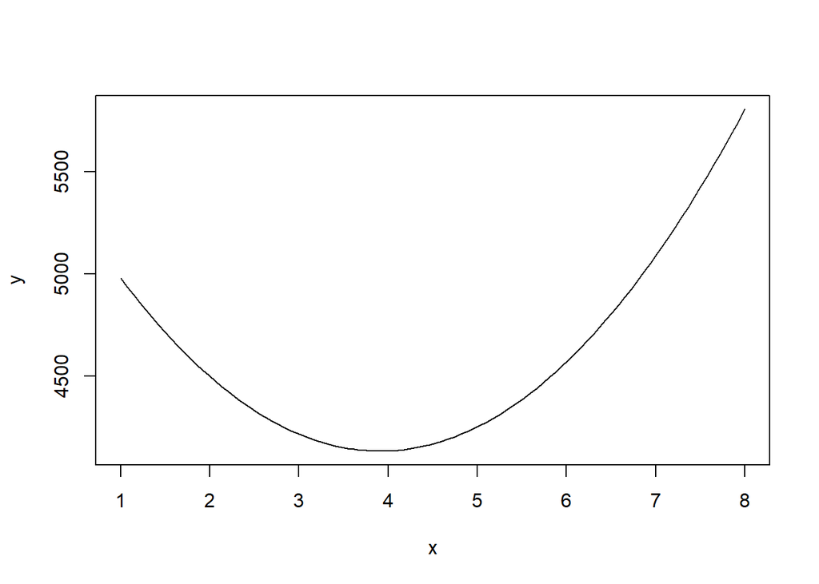

```r
plotCurve(lsFun, x, 1, 8)
```

We can see that the minimum lies somewhere between $\mu = 1$ and $\mu = 8$, pretty close to $\mu = 4$. From Question 2.1, we know that the mean of `x` is equal to 3.91.

- To verify that the mean of `x` minimizes the sum of squared deviations, change the range of the x-axis in the plot to zoom in on 3.91.

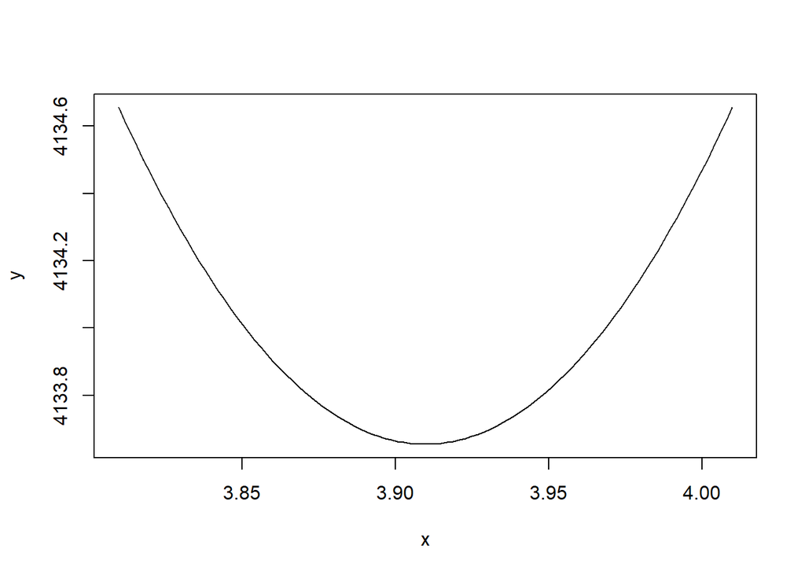

```r
plotCurve(lsFun, x, mean(x) - 0.1, mean(x) + 0.1)
```

# 4 More Least Squares Fun

In this section, you will analyze the `y` variable that you loaded via the `exercise4_data.RData` workspace.

## 4.1

**Plot a histogram of `y`**

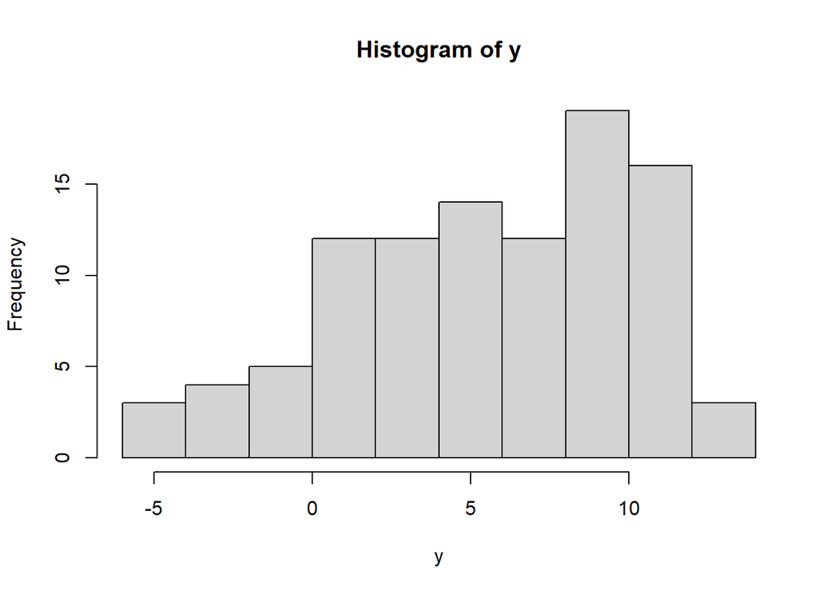

```r
hist(y)
```

## 4.2

**Calculate the sample mean of `y`**

```r
mean(y)
```

```
## [1] 5.474064
```

## 4.3

**Calculate the median of `y`**

```r
median(y)
```

```
## [1] 6.037784
```

## 4.4

**What do the relative values of the mean and the median tell you about the shape of the data?**

The median is larger than the mean. This difference suggest that the distribution of `y` is negatively skewed. The histogram clearly shows this skew.

- If we plot the density, the skew is even more apparent.

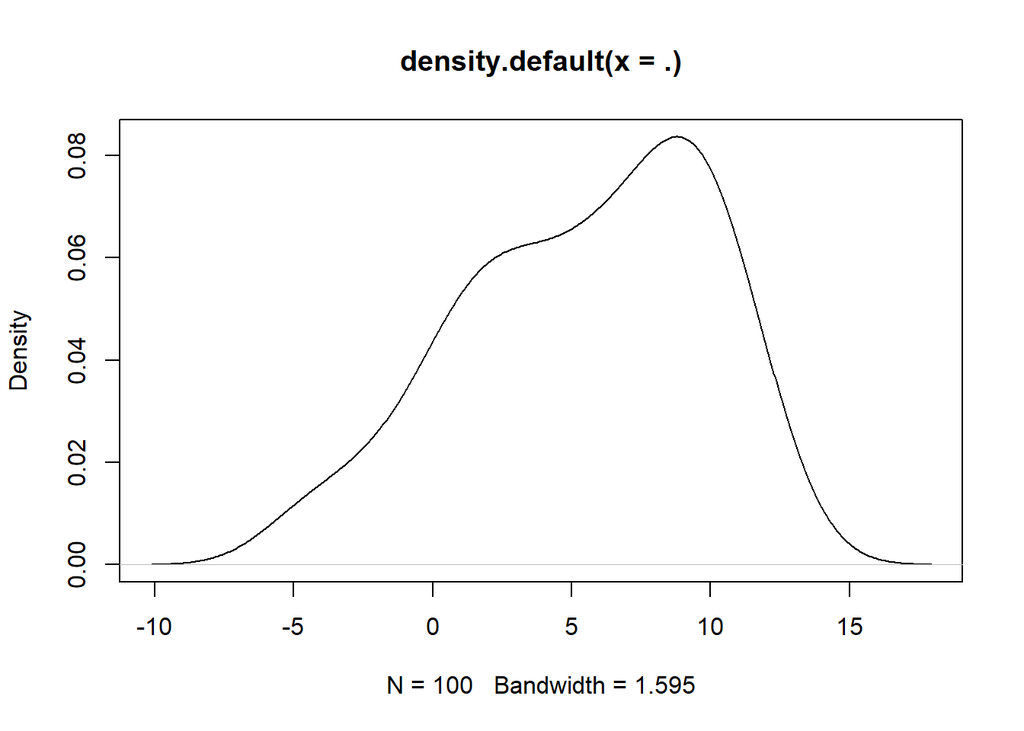

```r
y %>% density() %>% plot()
```

## 4.5

**Plot the least squares solutions**

Use the `plotCurve()` function from above to plot the curve of least squares solutions for the range $\mu = 2$ to $\mu = 10$.

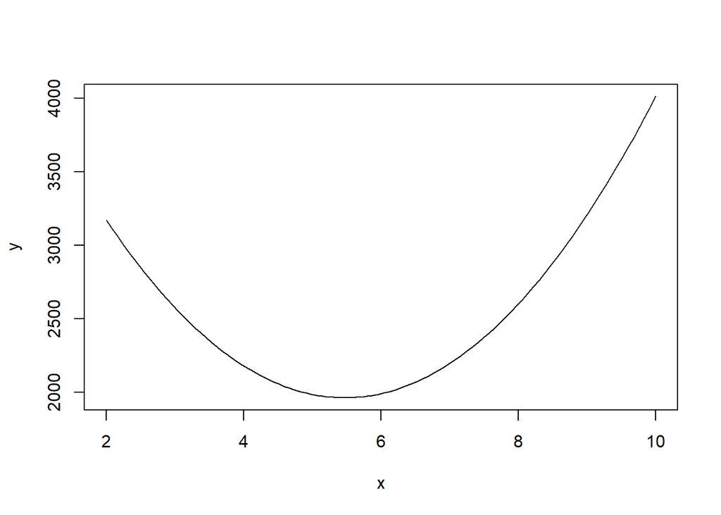

```r
plotCurve(lsFun, y, 2, 10)
```

## 4.6

**Plot a curve that zooms in on the minimum of the above figure**

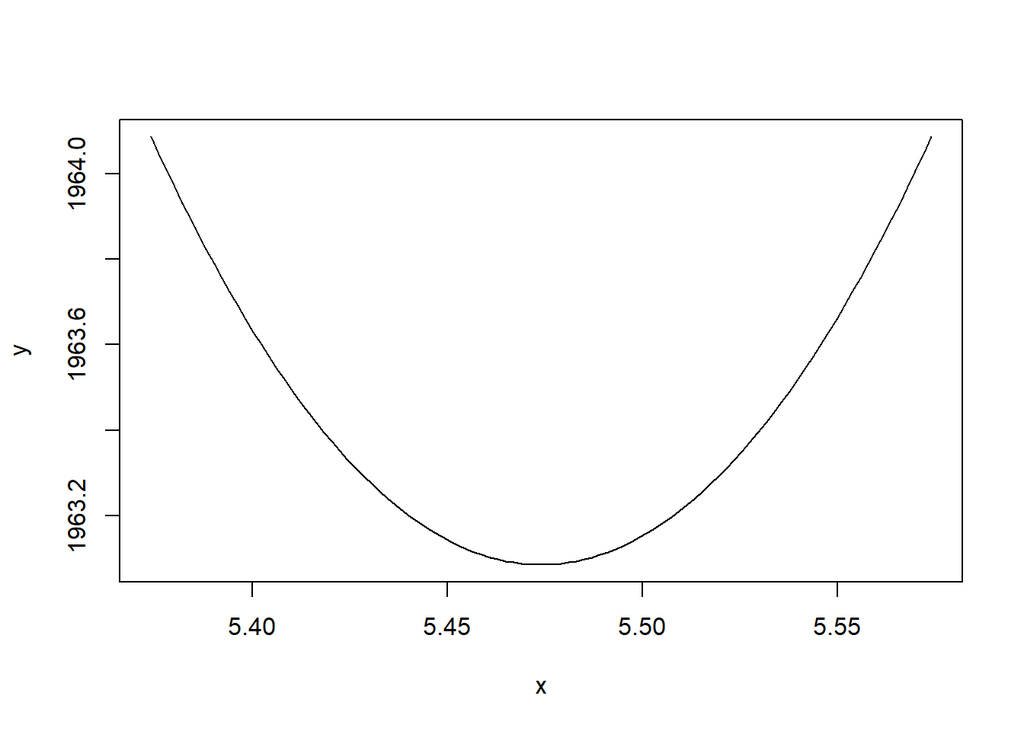

```r
plotCurve(lsFun, y, mean(y) - 0.1, mean(y) + 0.1)
```

## 4.7

**What value of $\mu$ would minimize the sum of squared deviations?**

Naturally, the sample mean of `y`, 5.474, minimizes the sum of squared deviations.

End of Exercise 4

# 5 Useful Links

Here are some useful links related to the topics covered in this exercise.

- [**magrittr**](https://magrittr.tidyverse.org)
- [R for Data Science](http://r4ds.had.co.nz)
  - [Chapter 18 on pipes](http://r4ds.had.co.nz/pipes.html)